# M2P3 Multiple Regression

NF

18-10-2019

# EXECUTIVE SUMMARY

This analysis focus is on determination of how different product types perform against eachother and how type of products might impact sales. Service- and customer reviews are considered the most impactfuls for boosting sales and are therefore taken into account.

## The approach

The approach of the analysis is to analyse historical sales data and then make sales predictions for four different product types being Netbook, PC, Laptop and Smartphone.

For impact of sales volume the service- and customer reviews were used as relevant influencer for sales volume.

# PREPROCESS

In order to do a proper analysis the data was checked for missing values and type of variables. Using the dummify function within R converted character and factor values to dummy (binary) values.

## Feature selection

```r
relevant_vars
```

```
##  [1] "ProductTypeLaptop"     "ProductTypeNetbook"
##  [3] "ProductTypePC"         "ProductTypeSmartphone"
##  [5] "ProductNum"            "x5StarReviews"
##  [7] "x4StarReviews"         "x3StarReviews"
##  [9] "x2StarReviews"         "x1StarReviews"
## [11] "PositiveServiceReview" "NegativeServiceReview"
## [13] "Recommendproduct"      "Volume"
```

## Plot Correlation Matrix

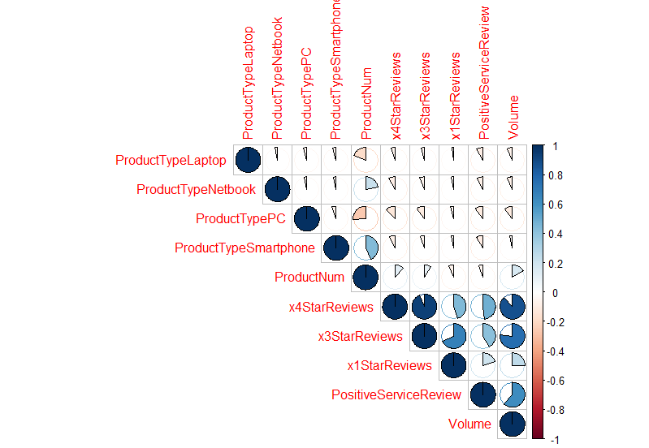

Plot Upper Right Correlation Matrix

# MODELLING

After defining a sample set and test and train sets the following models were trained and test on performance in predicting sales volume and per product type.

- MODELS
  - Linear Model
  - Random Forest
  - KNN
  - SVM

Based on the performance indicators the Random Forest (RF) had the best results:

> Rsquared 0.865

RF postresample -> postResample(pred = predict(object = rfFit, newdata = testingrf), obs = testingrf$Volume)

> Rsquared 0.94 and a significant lower RMSE (160)

# MODEL ERROR CHECK

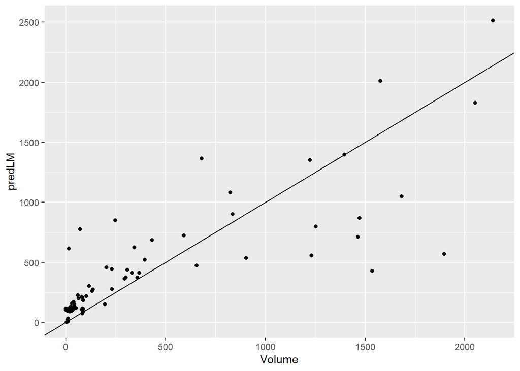

```r
plot(PlotErrorCheck)
```

## Remove outliers

First the values of the outliers were detected.

```r
outlier_values
```

```
## [1] 11204  7036
```

To further improve the data features are renamed in shorter versions and the two rows containing the outliers were removed. Also the 1 Star reviews are removed to further improve the performance of the models: Finaldf_cleaned <- distinct(.data = final_df_ExOut, PosSerRev, x4Star, x3Star, Volume, .keep_all = TRUE)

Finally duplicates of the product type Extended Warranty were brought back to one row.

## 2nd iteration of modelling

Also the performance was test based on the test set: postResample(pred = predict(object = rfFit2, newdata = testingrf2), obs = testingrf2$Volume) RMSE Rsquared MAE 137.120 0.9509 109.22

Based on the outcomes the **Random Forest model** is chosen to predict the volumes of the *new product selection*.

```r
rfFit <- readRDS("rfFit2.rds")
```

The plot below shows the predictions for smartphone sales by the trained model.

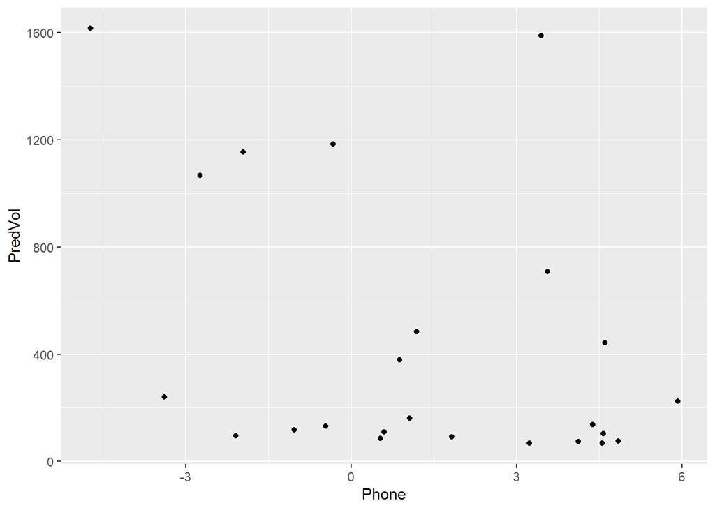

```r
plot(PlotPhone)
```

# PREPROCES PREDICTION

To predict salesvolume for the ProductTypes Netbook, PC, Smartphone and PC the New product data file is imported. All preprocessing, selecting relevant feautures etc. was also executed on this data frame. Including the final chosen impactful features for boosting sales.

```
## [1] "ProductTypeLaptop"     "ProductTypeNetbook"    "ProductTypePC"
## [4] "ProductTypeSmartphone" "ProductNum"            "x4StarReviews"
## [7] "x3StarReviews"         "PositiveServiceReview" "Volume"
```

Also the not chosen ProductTypes; *Accessoires ,Display, Extended Warranty, GameConsole, Printers, Printer Supplies, SoftWare & Tablet* were excluded for predictions.

# PREDICTION

```r
kable(head(NewData)) %>%
  kable_styling()
```

| Laptop | Netbook | PC | Phone | ID | Price | x5Star | x4Star | x3Star | x2Star | x1Star | PosSerRev | NegSerRev | RecProd | Weight | Depth | Width | Height | PMargin | Volume | PredVol |
| --- | --- | --- | --- | --- | --- | --- | --- | --- | --- | --- | --- | --- | --- | --- | --- | --- | --- | --- | --- | --- |
| 0 | 0 | 1 | 0 | 171 | 699.00 | 96 | 26 | 14 | 14 | 25 | 12 | 3 | 0.7 | 19.9 | 20.63 | 19.25 | 8.39 | 0.25 | 0 | 446.74216 |
| 0 | 0 | 1 | 0 | 172 | 860.00 | 51 | 11 | 10 | 10 | 21 | 7 | 5 | 0.6 | 27.0 | 21.89 | 27.01 | 9.13 | 0.20 | 0 | 157.04195 |
| 1 | 0 | 0 | 0 | 173 | 1199.00 | 74 | 10 | 3 | 3 | 11 | 11 | 5 | 0.8 | 6.6 | 8.94 | 12.80 | 0.68 | 0.10 | 0 | 238.45083 |
| 1 | 0 | 0 | 0 | 175 | 1199.00 | 7 | 2 | 1 | 1 | 1 | 2 | 1 | 0.6 | 13.0 | 16.30 | 10.80 | 1.40 | 0.15 | 0 | 113.28460 |
| 1 | 0 | 0 | 0 | 176 | 1999.00 | 1 | 1 | 1 | 3 | 0 | 0 | 1 | 0.3 | 11.6 | 16.81 | 10.90 | 0.88 | 0.23 | 0 | 101.06601 |
| 0 | 1 | 0 | 0 | 178 | 399.99 | 19 | 8 | 4 | 1 | 10 | 2 | 4 | 0.6 | 5.8 | 8.43 | 11.42 | 1.20 | 0.08 | 0 | 90.51769 |

# CONCLUSION & RECOMMENDATIONS

First it seems that there is a positive and strong relationship between the total number of starts and number of product sales. But it also needs to be noted that the supplied data files with historical & new products seems to have incorrect prices. Mostly it looks like some products have a duplicated number at the end. Therefore it is advised to improve and check the sales data and repeat the analysis done.

Based on the supplied input it seems that 2 Netbooks, 1 PC and two Smartphones have the best potential for boosting sales.Although the sales volume for the netbook could be incorrect due to earlier mentioned price issues in the data files.

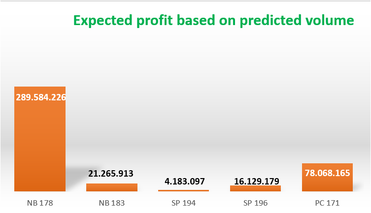

Graphic profit predicted sales volume